# Week 2 Assignment

```r
summary(Boston1)
```

```
##       crim                zn             indus            chas
##  Min.   : 0.00632   Min.   :  0.00   Min.   : 0.46   Min.   :0.00000
##  1st Qu.: 0.08204   1st Qu.:  0.00   1st Qu.: 5.19   1st Qu.:0.00000
##  Median : 0.25651   Median :  0.00   Median : 9.69   Median :0.00000
##  Mean   : 3.61352   Mean   : 11.36   Mean   :11.14   Mean   :0.06917
##  3rd Qu.: 3.67708   3rd Qu.: 12.50   3rd Qu.:18.10   3rd Qu.:0.00000
##  Max.   :88.97620   Max.   :100.00   Max.   :27.74   Max.   :1.00000
##       nox               rm             age              dis
##  Min.   :0.3850   Min.   :3.561   Min.   :  2.90   Min.   : 1.130
##  1st Qu.:0.4490   1st Qu.:5.886   1st Qu.: 45.02   1st Qu.: 2.100
##  Median :0.5380   Median :6.208   Median : 77.50   Median : 3.207
##  Mean   :0.5547   Mean   :6.285   Mean   : 68.57   Mean   : 3.795
##  3rd Qu.:0.6240   3rd Qu.:6.623   3rd Qu.: 94.08   3rd Qu.: 5.188
##  Max.   :0.8710   Max.   :8.780   Max.   :100.00   Max.   :12.127
##       rad              tax           ptratio          black
##  Min.   : 1.000   Min.   :187.0   Min.   :12.60   Min.   :  0.32
##  1st Qu.: 4.000   1st Qu.:279.0   1st Qu.:17.40   1st Qu.:375.38
##  Median : 5.000   Median :330.0   Median :19.05   Median :391.44
##  Mean   : 9.549   Mean   :408.2   Mean   :18.46   Mean   :356.67
##  3rd Qu.:24.000   3rd Qu.:666.0   3rd Qu.:20.20   3rd Qu.:396.23
##  Max.   :24.000   Max.   :711.0   Max.   :22.00   Max.   :396.90
##      lstat            medv
##  Min.   : 1.73   Min.   : 5.00
##  1st Qu.: 6.95   1st Qu.:17.02
##  Median :11.36   Median :21.20
##  Mean   :12.65   Mean   :22.53
##  3rd Qu.:16.95   3rd Qu.:25.00
##  Max.   :37.97   Max.   :50.00
```

```r
str(Boston1)
```

```
## 'data.frame':    506 obs. of  14 variables:
##  $ crim   : num  0.00632 0.02731 0.02729 0.03237 0.06905 ...
##  $ zn     : num  18 0 0 0 0 0 12.5 12.5 12.5 12.5 ...
##  $ indus  : num  2.31 7.07 7.07 2.18 2.18 2.18 7.87 7.87 7.87 7.87 ...
##  $ chas   : int  0 0 0 0 0 0 0 0 0 0 ...
##  $ nox    : num  0.538 0.469 0.469 0.458 0.458 0.458 0.524 0.524 0.524 0.524 ...
##  $ rm     : num  6.58 6.42 7.18 7 7.15 ...
##  $ age    : num  65.2 78.9 61.1 45.8 54.2 58.7 66.6 96.1 100 85.9 ...
##  $ dis    : num  4.09 4.97 4.97 6.06 6.06 ...
##  $ rad    : int  1 2 2 3 3 3 5 5 5 5 ...
##  $ tax    : num  296 242 242 222 222 222 311 311 311 311 ...
##  $ ptratio: num  15.3 17.8 17.8 18.7 18.7 18.7 15.2 15.2 15.2 15.2 ...
##  $ black  : num  397 397 393 395 397 ...
##  $ lstat  : num  4.98 9.14 4.03 2.94 5.33 ...
##  $ medv   : num  24 21.6 34.7 33.4 36.2 28.7 22.9 27.1 16.5 18.9 ...
```

3. Here I create 3 pairwise charts of 4 attributes to look for linear relationsips

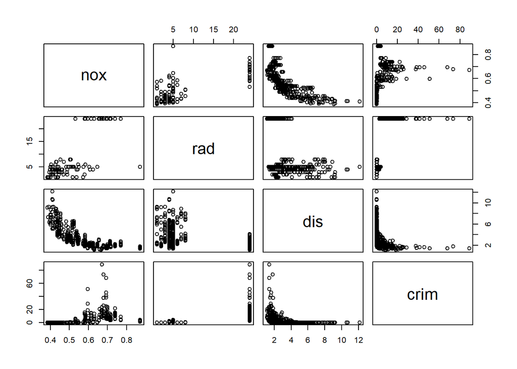

```r
Boston_1 <- subset(Boston1, select = c("nox", "rad", "dis", "crim"))
plot(Boston_1)
```

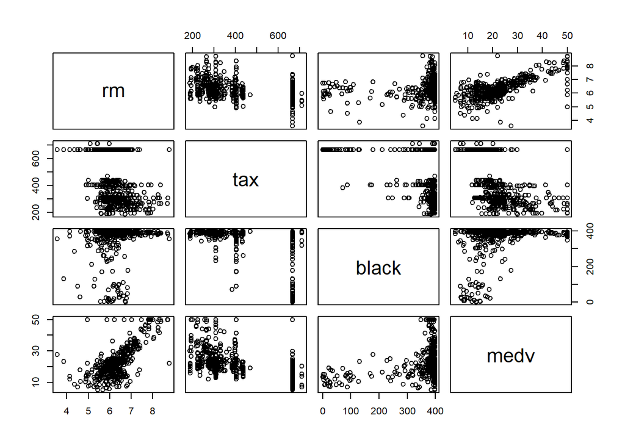

```r
Boston_2 <- subset(Boston1, select = c("rm", "tax", "black", "medv"))
plot(Boston_2)
```

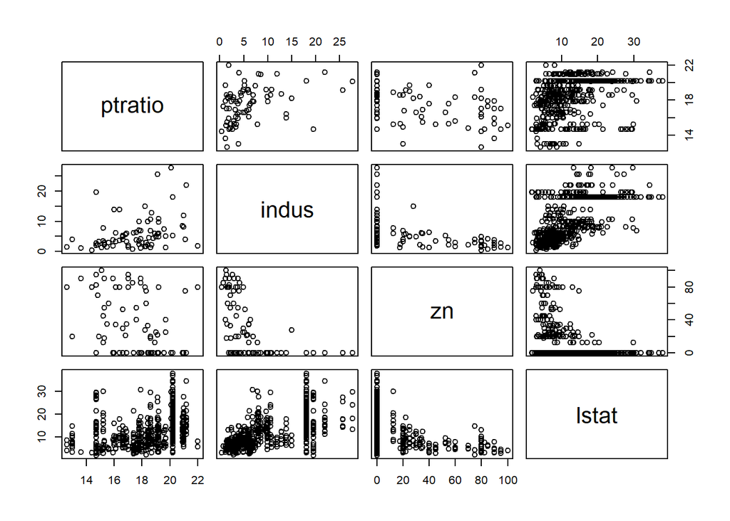

```r
Boston_3 <- subset(Boston1, select = c("ptratio", "indus", "zn", "lstat"))
plot(Boston_3)
```

When plotting the percentage of black people in a town to the median home value, it appears the larger the percentage of black people, the higher the variance in home prices. Most are clustered arougn 15-40k, but all homes above $40k have a higher black population.

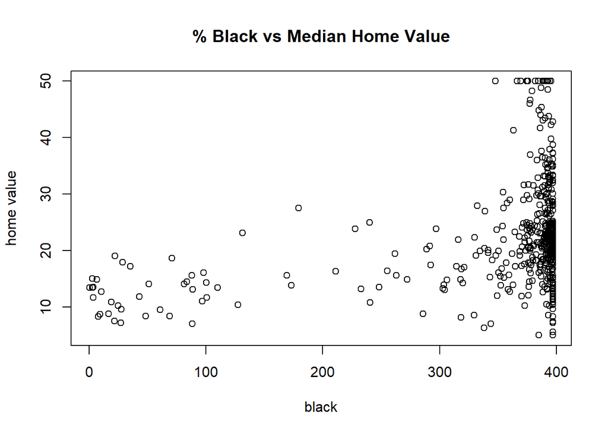

```r
plot(Boston1$black,
     Boston1$medv,
     main = "% Black vs Median Home Value",
     xlab = "black",
     ylab = "home value")
```

4. Below is a scatterplot that shows the relationship between median home value and the number of rooms in the home. This looks like it has the most linear appearance so I will use these features for my regression model. The objective here is to find out if number of rooms has a positive correlation with median home value.

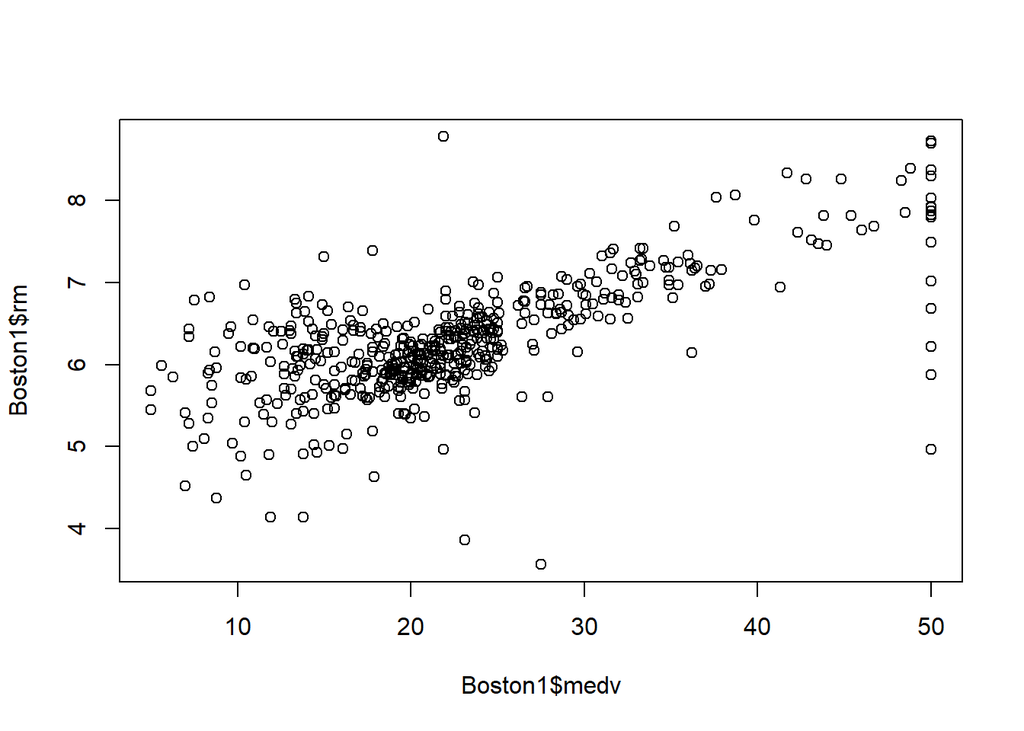

```r
plot(Boston1$medv, Boston1$rm)
```

```r
#correlation <- cor(Boston1$medv,Boston1$rm)
#print(correlation)
```

I noticed there’s a vertical line of points along the y axis at 50k, most likely representing homes over 50k.

```r
summary(Boston1$medv)
```

```
##    Min. 1st Qu.  Median    Mean 3rd Qu.    Max.
##    5.00   17.02   21.20   22.53   25.00   50.00
```

Removing values at 50k in my subset for modelling

```r
Boston2 <- subset(Boston1, select = c(rm, medv))
Boston2 <- Boston2[Boston2$medv != 50,]
```

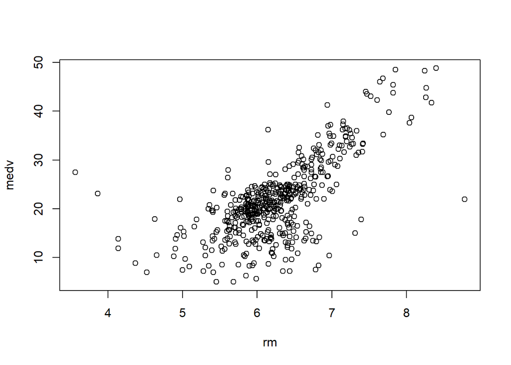

```r
plot(Boston2)
```

With a correlation of .68, there is a moderately strong linear relationship

```r
correlation <- cor(Boston2$medv,Boston2$rm)
print(correlation)
```

```
## [1] 0.6866343
```

5. Null Hypothesis (H0): There is no correlation between number of rooms and median value.

Alternative Hypothesis (H1): There is a positive correlation between number of rooms and median value.

6. Here I perform linear regression on the Boston2 subset

```r
Boston2.lm <- lm(medv~ rm, Boston2)
```

Displaying the results of the linear regression

```r
Boston2.lm
```

```
##
## Call:
## lm(formula = medv ~ rm, data = Boston2)
##
## Coefficients:
## (Intercept)           rm
##     -30.005        8.269
```

Here I’m able to see the coefficient of determination, the r squared value.

```r
summary(Boston2.lm)$r.squared
```

```
## [1] 0.4714667
```

7. There is a postive correlation between room size and the median value, however it is not extremely high. While room size is involved in calculating housing prices, I would say it is not the most determing factor.

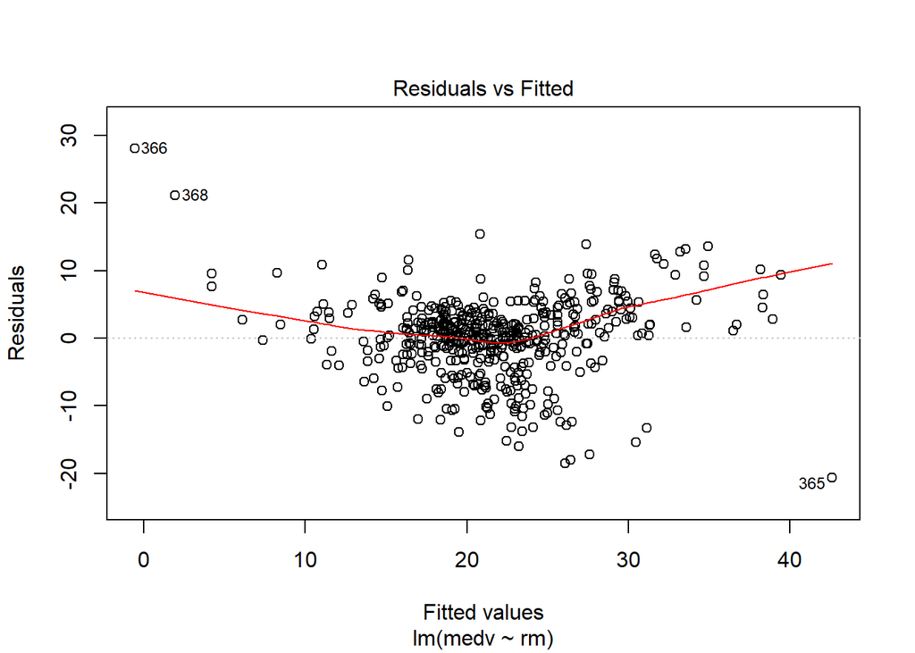

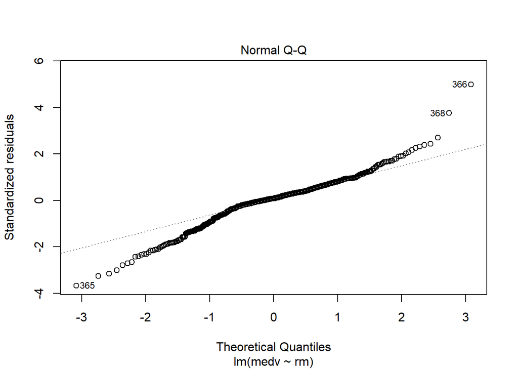

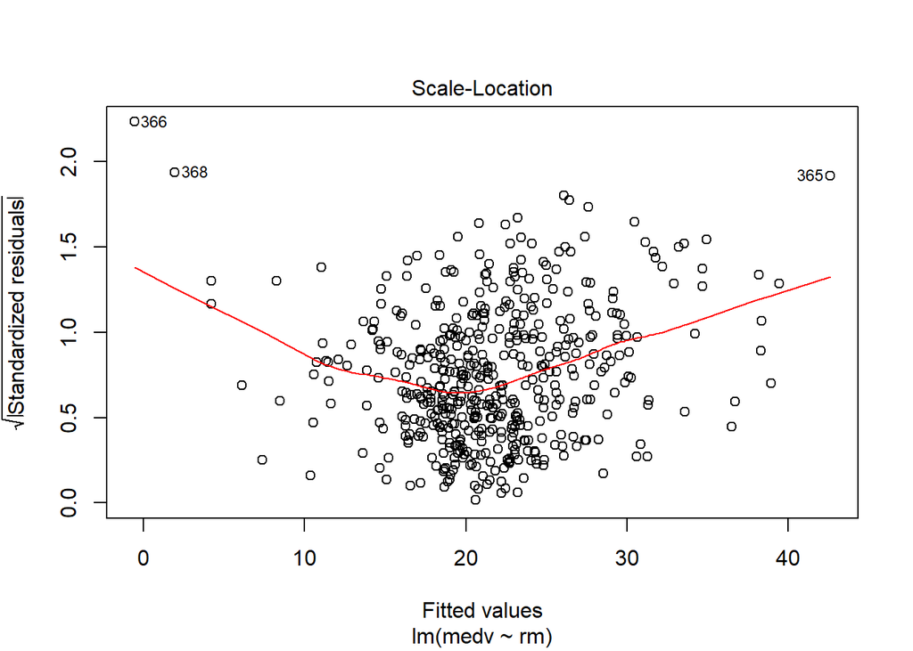

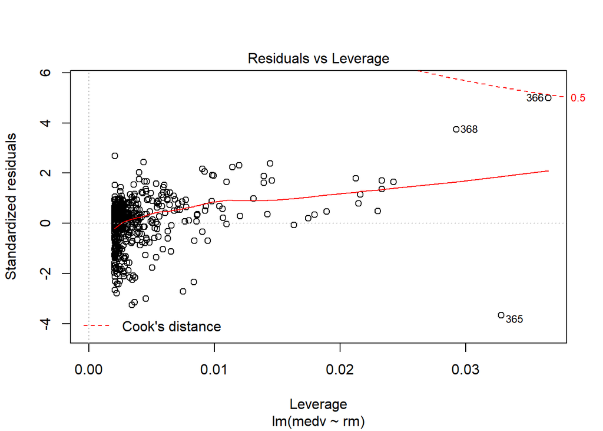

```r
plot(Boston2.lm)
```

8. Yes, there is evidence of a linear (positive) relationship between the number of rooms and median value. Here I make the decision to rejct the Null hypothesis (that there is no correlation between the two variables). I accept the alternative hypothesis.

```r
cor(Boston2,
    use = "all.obs", # Specifies the handling of missing data. Options are all.obs (assumes no missing data - missing data will produce an error), complete.obs (listwise deletion), and pairwise.complete.obs (pairwise deletion)
    method = "pearson" # Specifies the type of correlation. Options are pearson, spearman or kendall.
      )
```

```
##             rm      medv
## rm   1.0000000 0.6866343
## medv 0.6866343 1.0000000
```

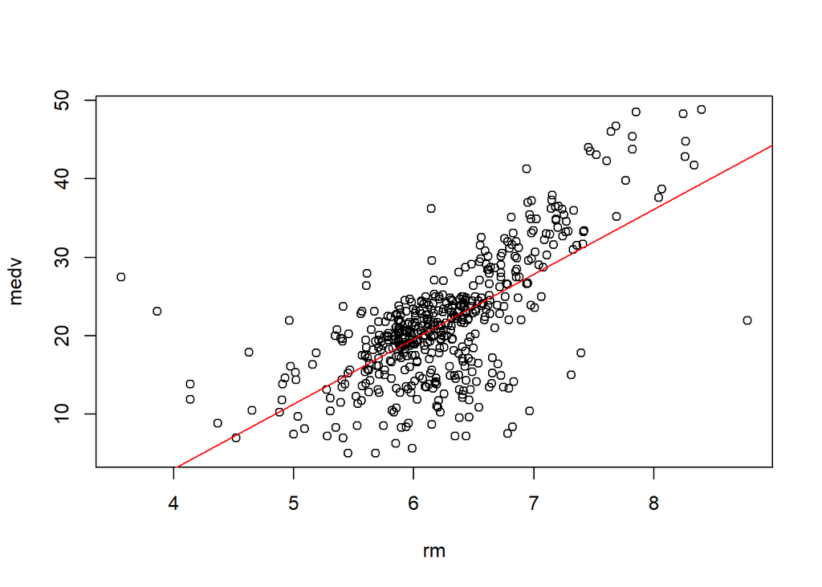

```r
plot(Boston2)
abline(lm(Boston2$medv~Boston2$rm), col="red")
```

10. I have not worked with implementing linear regression before so this was an interesting task in investigating linearity. I was not surprised by what I found, that the room size played a positive part in determining the median house value. It appears that this variable will be important in looking at multiple linear regression variables for the same response variable.